# Student Social Media Addiction

## About Dataset

### Overview

The Student Social Media & Relationships dataset contains anonymized records of students’ social‐media behaviors and related life outcomes. It spans multiple countries and academic levels, focusing on key dimensions such as usage intensity, platform preferences, and relationship dynamics. Each row represents one student’s survey response, offering a cross‐sectional snapshot suitable for statistical analysis and machine‐learning applications.

### Scope & Coverage

- **Population**: Students aged 16–25 enrolled in high school, undergraduate, or graduate programs.
- **Geography**: Multi‐country coverage (e.g., Bangladesh, India, USA, UK, Canada, Australia, Germany, Brazil, Japan, South Korea).
- **Timeframe**: Data collected via a one‐time online survey administered in Q1 2025.
- **Volume**: Configurable sample sizes (e.g., 100, 500, 1,000 records) based on research needs.

### Data Collection & Methodology

- **Survey Design**: Questions adapted from validated scales on social‐media addiction (e.g., Bergen Social Media Addiction Scale) and relationship conflict indices.
- **Recruitment**: Participants recruited through university mailing lists and social‐media platforms, ensuring diversity in academic level and country.
- **Data Quality Controls**:
  - **Validation**: Mandatory fields and range checks (e.g., usage hours between 0–24).
  - **De‐duplication**: Removal of duplicate entries via unique Student_ID checks.
  - **Anonymization**: No personally identifiable information collected.

## Key Variables

| **Variable** | **Type** | **Description** |
| --- | --- | --- |
| **Student_ID** | Integer | Unique respondent identifier |
| **Age** | Integer | Age in years |
| **Gender** | Categorical | “Male” or “Female” |
| **Academic_Level** | Categorical | High School / Undergraduate / Graduate |
| **Country** | Categorical | Country of residence |
| **Avg_Daily_Usage_Hours** | Float | Average hours per day on social media |
| **Most_Used_Platform** | Categorical | Instagram, Facebook, TikTok, etc. |
| **Affects_Academic_Performance** | Boolean | Self‐reported impact on academics (Yes/No) |
| **Sleep_Hours_Per_Night** | Float | Average nightly sleep hours |
| **Mental_Health_Score** | Integer | Self‐rated mental health (1 = poor to 10 = excellent) |
| **Relationship_Status** | Categorical | Single / In Relationship / Complicated |
| **Conflicts_Over_Social_Media** | Integer | Number of relationship conflicts due to social media |
| **Addicted_Score** | Integer | Social Media Addiction Score (1 = low to 10 = high) |

## Potential Analyses

- **Correlation Studies**: Examine associations between daily usage hours and mental health score or sleep hours.
- **Predictive Modeling**: Build classifiers to predict relationship conflicts based on usage patterns and platform type.
- **Clustering**: Identify user segments (e.g., “high‐usage high‐stress” vs. “moderate‐usage balanced”) across countries.

## Limitations

- **Self‐Report Bias**: All measures are self-reported and may be subject to social‐desirability effects.
- **Cross‐Sectional Design**: One‐time survey prevents causal inference.
- **Sampling Variability**: Recruitment via online channels may underrepresent students with limited internet access.

# Adicción a las Redes Sociales en Estudiantes

## Acerca del Conjunto de Datos

### Resumen

El conjunto de datos sobre la Adicción a las Redes Sociales y las Relaciones de los Estudiantes contiene registros anonimados del comportamiento de los estudiantes en redes sociales y los resultados de su vida relacionados. Cubre múltiples países y niveles académicos, centrándose en dimensiones clave como la intensidad de uso, las preferencias de plataformas y las dinámicas de las relaciones. Cada fila representa la respuesta de un estudiante en una encuesta, ofreciendo una instantánea transversal adecuada para análisis estadísticos y aplicaciones de aprendizaje automático.

### Alcance y Cobertura

- **Población**: Estudiantes de entre 16 y 25 años matriculados en programas de secundaria, pregrado o posgrado.
- **Geografía**: Cobertura multinacional (por ejemplo, Bangladesh, India, EE. UU., Reino Unido, Canadá, Australia, Alemania, Brasil, Japón, Corea del Sur).
- **Periodo de Tiempo**: Los datos se recopilaron a través de una encuesta en línea única administrada en el primer trimestre de 2025.
- **Volumen**: Tamaños de muestra configurables (por ejemplo, 100, 500, 1,000 registros) según las necesidades de investigación.

### Recolección de Datos y Metodología

- **Diseño de la Encuesta**: Las preguntas se adaptaron de escalas validadas sobre adicción a las redes sociales (por ejemplo, la Escala de Adicción a las Redes Sociales de Bergen) y los índices de conflictos en relaciones.
- **Reclutamiento**: Los participantes fueron reclutados a través de listas de correo universitarias y plataformas de redes sociales, asegurando diversidad en nivel académico y país.
- **Controles de Calidad de los Datos**:
  - **Validación**: Campos obligatorios y comprobaciones de rango (por ejemplo, horas de uso entre 0-24).
  - **Eliminación de duplicados**: Eliminación de entradas duplicadas mediante comprobaciones del identificador único del estudiante (Student_ID).
  - **Anonimización**: No se recopila información personal identificable.

## Variables Clave

| **Variable** | **Tipo** | **Descripción** |
| --- | --- | --- |
| **Student_ID** | Entero | Identificador único del encuestado |
| **Age** | Entero | Edad en años |
| **Gender** | Categórico | “Masculino” o “Femenino” |
| **Academic_Level** | Categórico | Secundaria / Pregrado / Posgrado |
| **Country** | Categórico | País de residencia |
| **Avg_Daily_Usage_Hours** | Flotante | Promedio de horas diarias en redes sociales |
| **Most_Used_Platform** | Categórico | Instagram, Facebook, TikTok, etc. |
| **Affects_Academic_Performance** | Booleano | Impacto autoinformado en el rendimiento académico (Sí/No) |
| **Sleep_Hours_Per_Night** | Flotante | Promedio de horas de sueño por noche |
| **Mental_Health_Score** | Entero | Autoevaluación de la salud mental (1 = pobre a 10 = excelente) |
| **Relationship_Status** | Categórico | Soltero / En relación / Complicado |
| **Conflicts_Over_Social_Media** | Entero | Número de conflictos en la relación debido a las redes sociales |
| **Addicted_Score** | Entero | Puntaje de adicción a las redes sociales (1 = bajo a 10 = alto) |

## Análisis Potenciales

- **Estudios de Correlación**: Examinar asociaciones entre horas de uso diarias y el puntaje de salud mental o las horas de sueño.
- **Modelado Predictivo**: Construir clasificadores para predecir conflictos en las relaciones basados en patrones de uso y tipo de plataforma.
- **Clustering**: Identificar segmentos de usuarios (por ejemplo, “alto uso y alto estrés” frente a “uso moderado y equilibrado”) a través de países.

## Limitaciones

- **Sesgo de Autoinforme**: Todas las medidas son autoinformadas y pueden estar sujetas a efectos de deseabilidad social.
- **Diseño Transversal**: La encuesta es de una sola vez, lo que impide inferir causalidad.
- **Variabilidad en el Muestreo**: El reclutamiento a través de canales en línea puede subrepresentar a estudiantes con acceso limitado a internet.

## Carga de datos

```python
import pandas as pd
import matplotlib.pyplot as plt
import numpy as np
import seaborn as sns
import joblib
import warnings
warnings.filterwarnings('ignore')
%matplotlib inline
```

```python
df = pd.read_csv('../data/raw/Students Social Media Addiction.csv')

df.head(5)
```

|  | Student_ID | Age | Gender | Academic_Level | Country | Avg_Daily_Usage_Hours | Most_Used_Platform | Affects_Academic_Performance | Sleep_Hours_Per_Night | Mental_Health_Score | Relationship_Status | Conflicts_Over_Social_Media | Addicted_Score |
| --- | --- | --- | --- | --- | --- | --- | --- | --- | --- | --- | --- | --- | --- |
| 0 | 1 | 19 | Female | Undergraduate | Bangladesh | 5.2 | Instagram | Yes | 6.5 | 6 | In Relationship | 3 | 8 |
| 1 | 2 | 22 | Male | Graduate | India | 2.1 | Twitter | No | 7.5 | 8 | Single | 0 | 3 |
| 2 | 3 | 20 | Female | Undergraduate | USA | 6.0 | TikTok | Yes | 5.0 | 5 | Complicated | 4 | 9 |
| 3 | 4 | 18 | Male | High School | UK | 3.0 | YouTube | No | 7.0 | 7 | Single | 1 | 4 |
| 4 | 5 | 21 | Male | Graduate | Canada | 4.5 | Facebook | Yes | 6.0 | 6 | In Relationship | 2 | 7 |

```python
df.columns
```

```
Index(['Student_ID', 'Age', 'Gender', 'Academic_Level', 'Country',
       'Avg_Daily_Usage_Hours', 'Most_Used_Platform',
       'Affects_Academic_Performance', 'Sleep_Hours_Per_Night',
       'Mental_Health_Score', 'Relationship_Status',
       'Conflicts_Over_Social_Media', 'Addicted_Score'],
      dtype='object')
```

```python
num_cols   = ['Student_ID', 'Age', 'Avg_Daily_Usage_Hours', 'Sleep_Hours_Per_Night', 'Mental_Health_Score',
             'Conflicts_Over_Social_Media', 'Addicted_Score']
cat_cols   = ['Gender', 'Academic_Level', 'Country', 'Most_Used_Platform', 'Relationship_Status']
target_col = 'Affects_Academic_Performance'
```

```python
df.describe()
```

|  | Student_ID | Age | Avg_Daily_Usage_Hours | Sleep_Hours_Per_Night | Mental_Health_Score | Conflicts_Over_Social_Media | Addicted_Score |
| --- | --- | --- | --- | --- | --- | --- | --- |
| count | 705.000000 | 705.000000 | 705.000000 | 705.000000 | 705.000000 | 705.000000 | 705.000000 |
| mean | 353.000000 | 20.659574 | 4.918723 | 6.868936 | 6.226950 | 2.849645 | 6.436879 |
| std | 203.660256 | 1.399217 | 1.257395 | 1.126848 | 1.105055 | 0.957968 | 1.587165 |
| min | 1.000000 | 18.000000 | 1.500000 | 3.800000 | 4.000000 | 0.000000 | 2.000000 |
| 25% | 177.000000 | 19.000000 | 4.100000 | 6.000000 | 5.000000 | 2.000000 | 5.000000 |
| 50% | 353.000000 | 21.000000 | 4.800000 | 6.900000 | 6.000000 | 3.000000 | 7.000000 |
| 75% | 529.000000 | 22.000000 | 5.800000 | 7.700000 | 7.000000 | 4.000000 | 8.000000 |
| max | 705.000000 | 24.000000 | 8.500000 | 9.600000 | 9.000000 | 5.000000 | 9.000000 |

```python
print(df.info())
print(df.isnull().sum())
```

```
<class 'pandas.core.frame.DataFrame'>
RangeIndex: 705 entries, 0 to 704
Data columns (total 13 columns):
 #   Column                        Non-Null Count  Dtype
---  ------                        --------------  -----
 0   Student_ID                    705 non-null    int64
 1   Age                           705 non-null    int64
 2   Gender                        705 non-null    object
 3   Academic_Level                705 non-null    object
 4   Country                       705 non-null    object
 5   Avg_Daily_Usage_Hours         705 non-null    float64
 6   Most_Used_Platform            705 non-null    object
 7   Affects_Academic_Performance  705 non-null    object
 8   Sleep_Hours_Per_Night         705 non-null    float64
 9   Mental_Health_Score           705 non-null    int64
 10  Relationship_Status           705 non-null    object
 11  Conflicts_Over_Social_Media   705 non-null    int64
 12  Addicted_Score                705 non-null    int64
dtypes: float64(2), int64(5), object(6)
memory usage: 71.7+ KB
None
Student_ID                      0
Age                             0
Gender                          0
Academic_Level                  0
Country                         0
Avg_Daily_Usage_Hours           0
Most_Used_Platform              0
Affects_Academic_Performance    0
Sleep_Hours_Per_Night           0
Mental_Health_Score             0
Relationship_Status             0
Conflicts_Over_Social_Media     0
Addicted_Score                  0
dtype: int64
```

## Análisis exploratorio de Datos(EDA)

```
array([[<Axes: title={'center': 'Student_ID'}>,
        <Axes: title={'center': 'Age'}>,
        <Axes: title={'center': 'Avg_Daily_Usage_Hours'}>],
       [<Axes: title={'center': 'Sleep_Hours_Per_Night'}>,
        <Axes: title={'center': 'Mental_Health_Score'}>,
        <Axes: title={'center': 'Conflicts_Over_Social_Media'}>],
       [<Axes: title={'center': 'Addicted_Score'}>, <Axes: >, <Axes: >]],
      dtype=object)
```

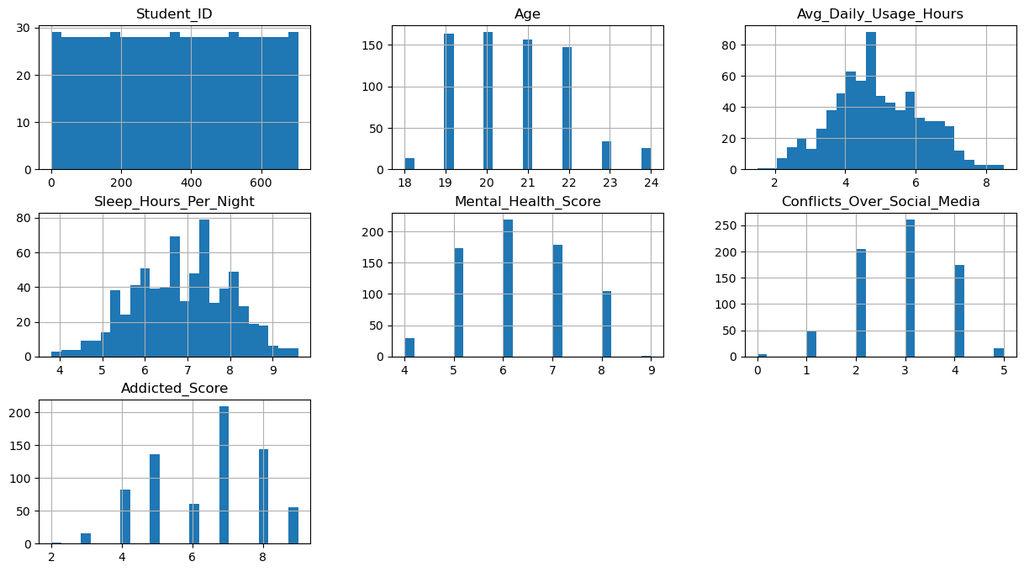

```python
df.hist(grid=True, bins=25, figsize=(15,8))
```

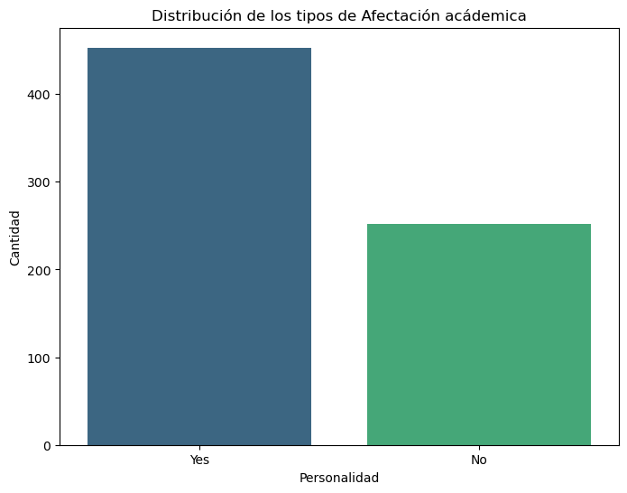

```python
plt.figure(figsize=(8, 6))
sns.countplot(x=target_col, data=df, palette='viridis')
plt.title('Distribución de los tipos de Afectación acádemica')
plt.xlabel('Personalidad')
plt.ylabel('Cantidad')
plt.show()
```

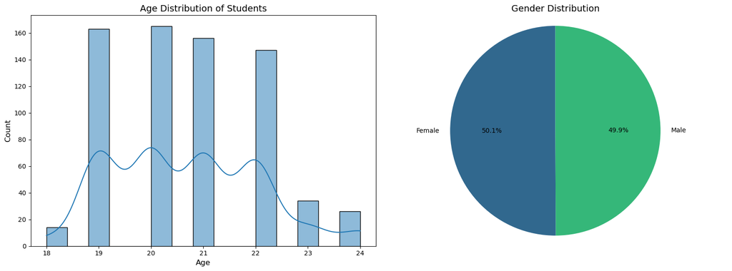

```python
# #### Age and Gender Distribution
plt.figure(figsize=(16, 6))

# Age distribution
plt.subplot(1, 2, 1)
sns.histplot(df['Age'], kde=True, bins=15)
plt.title('Age Distribution of Students', fontsize=14)
plt.xlabel('Age', fontsize=12)
plt.ylabel('Count', fontsize=12)

# Gender distribution
plt.subplot(1, 2, 2)
gender_counts = df['Gender'].value_counts()
plt.pie(gender_counts, labels=gender_counts.index, autopct='%1.1f%%', startangle=90, colors=sns.color_palette('viridis', len(gender_counts)))
plt.title('Gender Distribution', fontsize=14)
plt.axis('equal')

plt.tight_layout()
plt.savefig('../figures/Age_Gender_Distribution')
plt.show()
```

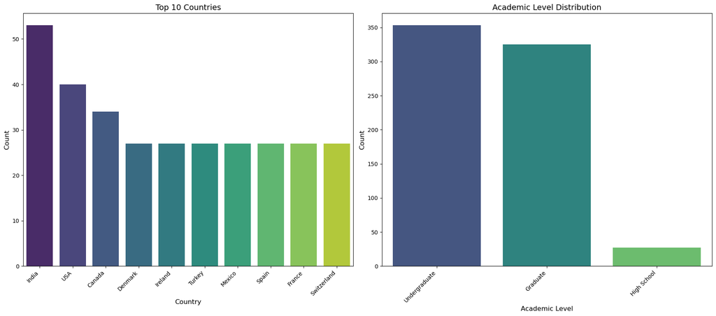

```python
plt.figure(figsize=(18, 8))

# Country distribution
plt.subplot(1, 2, 1)
country_counts = df['Country'].value_counts().head(10)
sns.barplot(x=country_counts.index, y=country_counts.values, palette='viridis')
plt.title('Top 10 Countries', fontsize=14)
plt.xlabel('Country', fontsize=12)
plt.ylabel('Count', fontsize=12)
plt.xticks(rotation=45, ha='right')

# Academic level distribution
plt.subplot(1, 2, 2)
academic_counts = df['Academic_Level'].value_counts()
sns.barplot(x=academic_counts.index, y=academic_counts.values, palette='viridis')
plt.title('Academic Level Distribution', fontsize=14)
plt.xlabel('Academic Level', fontsize=12)
plt.ylabel('Count', fontsize=12)
plt.xticks(rotation=45, ha='right')

plt.tight_layout()
plt.savefig('../figures/Country_AcademicLev_Distribution')
plt.show()
```

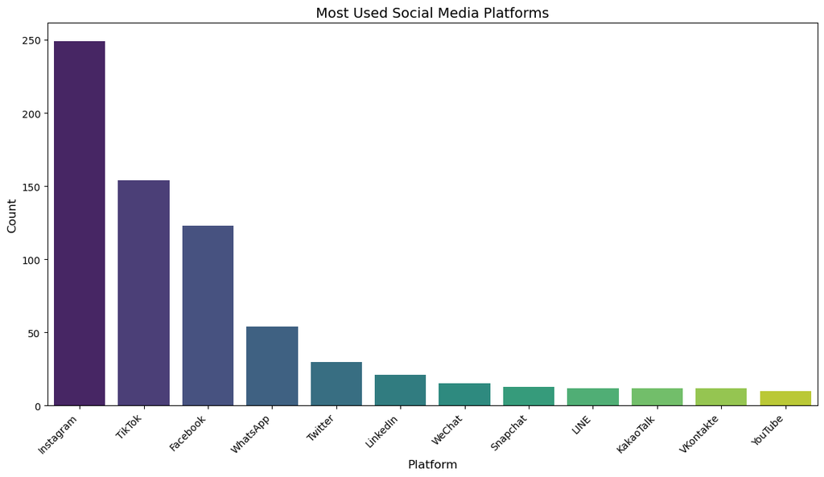

```python
# #### Most Used Platforms
plt.figure(figsize=(14, 7))
platform_counts = df['Most_Used_Platform'].value_counts()
sns.barplot(x=platform_counts.index, y=platform_counts.values, palette='viridis')
plt.title('Most Used Social Media Platforms', fontsize=14)
plt.xlabel('Platform', fontsize=12)
plt.ylabel('Count', fontsize=12)
plt.xticks(rotation=45, ha='right')
plt.savefig('../figures/Most_Used_Social_Media_Distribution')
plt.show()
```

```python
# #### Academic Performance vs Social Media Usage
import plotly.express as px
fig = px.box(df, x='Affects_Academic_Performance', y='Avg_Daily_Usage_Hours',
              title='Social Media Usage Hours vs. Impact on Academic Performance',
              labels={'Affects_Academic_Performance': 'Does it Affect Academic Performance?',
                     'Avg_Daily_Usage_Hours': 'Average Daily Usage Hours'})
fig.update_layout(width=800, height=500)
fig.show()
```

[output not shown]

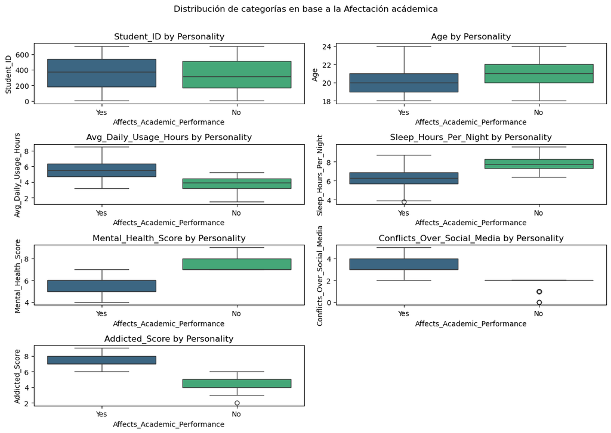

```python
plt.figure(figsize=(12, 8))
for i, col in enumerate(num_cols, 1):
    plt.subplot(4, 2, i)
    sns.boxplot(x=target_col, y=col, data=df, palette='viridis')
    plt.title(f'{col} by Personality')
plt.tight_layout()
plt.suptitle('Distribución de categorías en base a la Afectación acádemica', y=1.05)
plt.savefig('../figures/distCatPorAfectAcad.png')
plt.show()
```

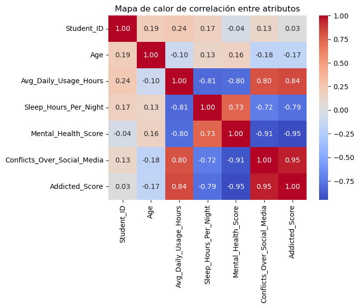

```python
corr_matrix = df[num_cols].corr(method='spearman')
sns.heatmap(corr_matrix, annot=True, fmt=".2f", cmap='coolwarm')
plt.title('Mapa de calor de correlación entre atributos')
plt.savefig('../figures/mapaCalorCorrelacion.png')
plt.show()
```

## Creación de nuevas características

```python
# Crear nuevas características
# Interacción entre Género y Nivel Académico
df['Gender_Academic_Interaction'] = df['Gender'].astype(str) + "_" + df['Academic_Level'].astype(str)

# Interacción entre Plataforma y Estado de Relación
df['Platform_Relationship_Interaction'] = df['Most_Used_Platform'] + "_" + df['Relationship_Status']

# Clasificación de uso de redes sociales (Bajo, Medio, Alto)
def usage_category(hours):
    if hours <= 2:
        return 0  # Bajo
    elif hours <= 5:
        return 1  # Medio
    else:
        return 2  # Alto

df['Usage_Category'] = df['Avg_Daily_Usage_Hours'].apply(usage_category)

# Variables derivadas de salud mental y sueño
df['Mental_Health_Risk'] = df['Mental_Health_Score'] - df['Sleep_Hours_Per_Night']
df['Sleep_Usage_Discrepancy'] = df['Sleep_Hours_Per_Night'] - df['Avg_Daily_Usage_Hours']

# Estrés acumulado en relaciones por redes sociales
df['Relationship_Stress'] = df['Conflicts_Over_Social_Media'] * df['Addicted_Score']

# Interacción entre adicción a redes sociales y rendimiento académico
df['Addiction_Affects_Academic'] = df['Addicted_Score'] * df['Affects_Academic_Performance'].map({'Yes': 1, 'No': 0}).astype(int)

# Variables de comportamiento en redes sociales
# Definir plataformas populares
popular_platforms = ['Instagram', 'Facebook', 'TikTok']

# Frecuencia de uso de plataformas populares
df['Frequent_Use_Popular_Platforms'] = df['Most_Used_Platform'].apply(lambda x: 1 if x in popular_platforms else 0)

# Impacto del uso de redes sociales en función de la plataforma
df['Social_Media_Usage_Impact'] = df['Avg_Daily_Usage_Hours'] * df['Most_Used_Platform'].apply(lambda x: 2 if x in ['Instagram', 'TikTok'] else 1)

# Promedios por país
df['Avg_Country_Usage'] = df.groupby('Country')['Avg_Daily_Usage_Hours'].transform('mean')
df['Avg_Country_Mental_Health'] = df.groupby('Country')['Mental_Health_Score'].transform('mean')

# Visualización de las primeras filas para revisar los datos
df.head(5)
```

|  | Student_ID | Age | Gender | Academic_Level | Country | Avg_Daily_Usage_Hours | Most_Used_Platform | Affects_Academic_Performance | Sleep_Hours_Per_Night | Mental_Health_Score | ... | Platform_Relationship_Interaction | Usage_Category | Mental_Health_Risk | Sleep_Usage_Discrepancy | Relationship_Stress | Addiction_Affects_Academic | Frequent_Use_Popular_Platforms | Social_Media_Usage_Impact | Avg_Country_Usage | Avg_Country_Mental_Health |
| --- | --- | --- | --- | --- | --- | --- | --- | --- | --- | --- | --- | --- | --- | --- | --- | --- | --- | --- | --- | --- | --- |
| 0 | 1 | 19 | Female | Undergraduate | Bangladesh | 5.2 | Instagram | Yes | 6.5 | 6 | ... | Instagram_In Relationship | 2 | -0.5 | 1.3 | 24 | 8 | 1 | 10.4 | 4.800000 | 5.050000 |
| 1 | 2 | 22 | Male | Graduate | India | 2.1 | Twitter | No | 7.5 | 8 | ... | Twitter_Single | 1 | 0.5 | 5.4 | 0 | 0 | 0 | 2.1 | 6.116981 | 5.452830 |
| 2 | 3 | 20 | Female | Undergraduate | USA | 6.0 | TikTok | Yes | 5.0 | 5 | ... | TikTok_Complicated | 2 | 0.0 | -1.0 | 36 | 9 | 1 | 12.0 | 6.890000 | 4.900000 |
| 3 | 4 | 18 | Male | High School | UK | 3.0 | YouTube | No | 7.0 | 7 | ... | YouTube_Single | 1 | 0.0 | 4.0 | 4 | 0 | 0 | 3.0 | 5.472727 | 5.681818 |
| 4 | 5 | 21 | Male | Graduate | Canada | 4.5 | Facebook | Yes | 6.0 | 6 | ... | Facebook_In Relationship | 1 | 0.0 | 1.5 | 14 | 7 | 1 | 4.5 | 4.714706 | 6.235294 |

5 rows × 24 columns

## Procesamiento de los datos

```python
for col in cat_cols:
    print(col)
    print(df[col].unique())
```

```
Gender
['Female' 'Male']
Academic_Level
['Undergraduate' 'Graduate' 'High School']
Country
['Bangladesh' 'India' 'USA' 'UK' 'Canada' 'Australia' 'Germany' 'Brazil'
 'Japan' 'South Korea' 'France' 'Spain' 'Italy' 'Mexico' 'Russia' 'China'
 'Sweden' 'Norway' 'Denmark' 'Netherlands' 'Belgium' 'Switzerland'
 'Austria' 'Portugal' 'Greece' 'Ireland' 'New Zealand' 'Singapore'
 'Malaysia' 'Thailand' 'Vietnam' 'Philippines' 'Indonesia' 'Taiwan'
 'Hong Kong' 'Turkey' 'Israel' 'UAE' 'Egypt' 'Morocco' 'South Africa'
 'Nigeria' 'Kenya' 'Ghana' 'Argentina' 'Chile' 'Colombia' 'Peru'
 'Venezuela' 'Ecuador' 'Uruguay' 'Paraguay' 'Bolivia' 'Costa Rica'
 'Panama' 'Jamaica' 'Trinidad' 'Bahamas' 'Iceland' 'Finland' 'Poland'
 'Romania' 'Hungary' 'Czech Republic' 'Slovakia' 'Croatia' 'Serbia'
 'Slovenia' 'Bulgaria' 'Estonia' 'Latvia' 'Lithuania' 'Ukraine' 'Moldova'
 'Belarus' 'Kazakhstan' 'Uzbekistan' 'Kyrgyzstan' 'Tajikistan' 'Armenia'
 'Georgia' 'Azerbaijan' 'Cyprus' 'Malta' 'Luxembourg' 'Monaco' 'Andorra'
 'San Marino' 'Vatican City' 'Liechtenstein' 'Montenegro' 'Albania'
 'North Macedonia' 'Kosovo' 'Bosnia' 'Qatar' 'Kuwait' 'Bahrain' 'Oman'
 'Jordan' 'Lebanon' 'Iraq' 'Yemen' 'Syria' 'Afghanistan' 'Pakistan'
 'Nepal' 'Bhutan' 'Sri Lanka' 'Maldives']
Most_Used_Platform
['Instagram' 'Twitter' 'TikTok' 'YouTube' 'Facebook' 'LinkedIn' 'Snapchat'
 'LINE' 'KakaoTalk' 'VKontakte' 'WhatsApp' 'WeChat']
Relationship_Status
['In Relationship' 'Single' 'Complicated']
```

```python
from sklearn.preprocessing import LabelEncoder

# Inicializar el codificador
le = LabelEncoder()

# Codificar las columnas categóricas con Label Encoding
df['Gender'] = le.fit_transform(df['Gender'])
df['Academic_Level'] = le.fit_transform(df['Academic_Level'])
df['Relationship_Status'] = le.fit_transform(df['Relationship_Status'])

# Codificar las interacciones generadas con Label Encoding
df['Gender_Academic_Interaction'] = le.fit_transform(df['Gender_Academic_Interaction'])
df['Platform_Relationship_Interaction'] = le.fit_transform(df['Platform_Relationship_Interaction'])

# One-Hot Encoding para las columnas 'Country' y 'Most_Used_Platform'
df = pd.get_dummies(df, columns=['Country', 'Most_Used_Platform'])

# Visualización del DataFrame con las modificaciones
df.head(5)
```

|  | Student_ID | Age | Gender | Academic_Level | Avg_Daily_Usage_Hours | Affects_Academic_Performance | Sleep_Hours_Per_Night | Mental_Health_Score | Relationship_Status | Conflicts_Over_Social_Media | ... | Most_Used_Platform_KakaoTalk | Most_Used_Platform_LINE | Most_Used_Platform_LinkedIn | Most_Used_Platform_Snapchat | Most_Used_Platform_TikTok | Most_Used_Platform_Twitter | Most_Used_Platform_VKontakte | Most_Used_Platform_WeChat | Most_Used_Platform_WhatsApp | Most_Used_Platform_YouTube |
| --- | --- | --- | --- | --- | --- | --- | --- | --- | --- | --- | --- | --- | --- | --- | --- | --- | --- | --- | --- | --- | --- |
| 0 | 1 | 19 | 0 | 2 | 5.2 | Yes | 6.5 | 6 | 1 | 3 | ... | False | False | False | False | False | False | False | False | False | False |
| 1 | 2 | 22 | 1 | 0 | 2.1 | No | 7.5 | 8 | 2 | 0 | ... | False | False | False | False | False | True | False | False | False | False |
| 2 | 3 | 20 | 0 | 2 | 6.0 | Yes | 5.0 | 5 | 0 | 4 | ... | False | False | False | False | True | False | False | False | False | False |
| 3 | 4 | 18 | 1 | 1 | 3.0 | No | 7.0 | 7 | 2 | 1 | ... | False | False | False | False | False | False | False | False | False | True |
| 4 | 5 | 21 | 1 | 0 | 4.5 | Yes | 6.0 | 6 | 1 | 2 | ... | False | False | False | False | False | False | False | False | False | False |

5 rows × 144 columns

```python
df.shape
```

```
(705, 144)
```

```python
df.head(5)
```

|  | Student_ID | Age | Gender | Academic_Level | Avg_Daily_Usage_Hours | Affects_Academic_Performance | Sleep_Hours_Per_Night | Mental_Health_Score | Relationship_Status | Conflicts_Over_Social_Media | ... | Most_Used_Platform_KakaoTalk | Most_Used_Platform_LINE | Most_Used_Platform_LinkedIn | Most_Used_Platform_Snapchat | Most_Used_Platform_TikTok | Most_Used_Platform_Twitter | Most_Used_Platform_VKontakte | Most_Used_Platform_WeChat | Most_Used_Platform_WhatsApp | Most_Used_Platform_YouTube |
| --- | --- | --- | --- | --- | --- | --- | --- | --- | --- | --- | --- | --- | --- | --- | --- | --- | --- | --- | --- | --- | --- |
| 0 | 1 | 19 | 0 | 2 | 5.2 | Yes | 6.5 | 6 | 1 | 3 | ... | False | False | False | False | False | False | False | False | False | False |
| 1 | 2 | 22 | 1 | 0 | 2.1 | No | 7.5 | 8 | 2 | 0 | ... | False | False | False | False | False | True | False | False | False | False |
| 2 | 3 | 20 | 0 | 2 | 6.0 | Yes | 5.0 | 5 | 0 | 4 | ... | False | False | False | False | True | False | False | False | False | False |
| 3 | 4 | 18 | 1 | 1 | 3.0 | No | 7.0 | 7 | 2 | 1 | ... | False | False | False | False | False | False | False | False | False | True |
| 4 | 5 | 21 | 1 | 0 | 4.5 | Yes | 6.0 | 6 | 1 | 2 | ... | False | False | False | False | False | False | False | False | False | False |

5 rows × 144 columns

```python
# Convertir la columna 'Affects_Academic_Performance' de tipo objeto a numérica
df['Affects_Academic_Performance'] = df['Affects_Academic_Performance'].map({'Yes': 1, 'No': 0})
```

```python
df.to_csv('../data/processed/processing_dataset.csv')
```

```python
from sklearn.model_selection import train_test_split

X = df.drop(columns=[target_col])
y = df[target_col]
X_train, X_test, y_train, y_test = train_test_split(X, y, test_size=0.2, stratify=y, random_state=42)
```

```python
from imblearn.over_sampling import SMOTE
from sklearn.preprocessing import StandardScaler

smote = SMOTE(random_state=42)
X_train, y_train = smote.fit_resample(X_train, y_train)

# Scale features
scaler = StandardScaler()
X_train_scaled = scaler.fit_transform(X_train)
X_test_scaled = scaler.transform(X_test)

target_encoder = LabelEncoder()
y_train = target_encoder.fit_transform(y_train)
y_test = target_encoder.transform(y_test)
```